# Marketing Campaign Optimization

Tony Blonigan

### Contents

1. Business Objective
2. Data Analysis
3. Propensity Scoring
4. Strategic plan
5. Next Steps
6. Appendix

# Business Objective

## Background

Springleaf is a personal lending company that provides subprime loans people can use to purchase consumer goods. The company wishes to improve its direct mail marketing campaign and has published [this](https://www.kaggle.com/c/springleaf-marketing-response/data) dataset for research. The goal of this project is not to simply create a predictive model that will increase the company's conversion rate, from a baseline of 23%, but also to illustrate a comprehensive marketing strategy and the value it can deliver to the company.

- Data
  - 145.2K rows
  - 1934 columns
    - 1882 columns are numeric
    - 51 columns are categorical
  - The column called 'target' indicates whether the opportunity was converted
- Objective
  - Improve promotional targeting
  - Increase conversion rate from baseline of 23%
  - Optimize profit through comprehensive marketing strategy

### Notes

- While I stuck to the data in building and evaluating models, some of the background is based off of unchecked assumptions. The point of this notebook is to illustrate how to leverage data to drive business objectives, not simply build predictive models. A business context makes this a much easier read, so I embellished some details that were not covered in the materials related to the original [dataset](https://www.kaggle.com/c/springleaf-marketing-response/data).
- Since the point of this is to illustrate a business case, I took some shortcuts with the model building, for example, I assumed all columns pandas interpreted as numeric were non-categorical; and I didn't check for outliers in any columns.

## Current Strategy

Currently, the company is using domain knowledge of in-house marketers to target broad market segments based on high-level, demographic indicators. For example, they know their conversion rate is higher among users in the North East (N.E.), so they send promotional literature to everyone in the N.E., on their client list. We can understand this as a crude method of propensity scoring (P.S.), where a higher P.S. corresponds to a higher probability of conversion. In this example people in the N.E. would have a higher P.S. than, say, people in the Mid-West.

We can visualize group of N.E. clients by representing each individual as a dot, where its P.S. represented by darkness of the dot (the higher the P.S., the darker the dot).

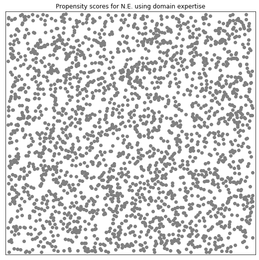

## Improved Propensity Scoring

As you can see in the plot above, while using coarse, demographic data to target customers is a good start to optimizing marketing campaigns, the resulting scores are not very precise. It would be much better if we could score each individual, but this becomes an intractable amount of work for domain experts to do. Better to automate this using machine learning.

To illustrate this idea, lets imagine what the scores machine learning could generate and think through the consequences.

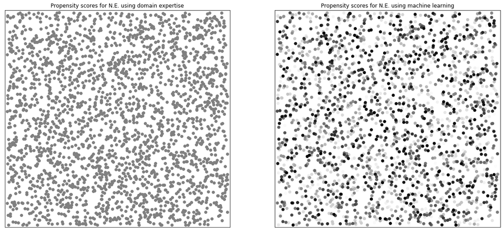

As illustrated above, using domain experts to set marketing targets results in a crude approximation of conversion propensity. This can be explained mostly by two limitations:

- It is difficult for humans to pull patterns out of a dataset with ~2k columns, leading to oversimplifications of the problem
- It is time consuming/expensive for humans to review each potential client before determining their propensity score

Fortunately, machine learning easily overcomes both of these limitations, allowing us to calculate much more precise propensity scores, like the ones in the right-hand chart above.

## Benefits

As we will demonstrate later on, more precise propensity scores will allow us to:

1. Reduce marketing costs by limiting promotional materials being sent to customers who will not convert, and
2. Maintain revenue generation by continuing to send promotional materials to customers who will convert.

To the extent that we are lowering costs faster than we are reducing revenue generation, we will increase both ROI and profit.

# Data Analysis

Before we can realize these benefits we have to train a model to score our customers. To illustrate the way our model will use the data in scoring customers, lets visualize some of the columns' relationships to the target variable.

## Numeric Correlations

We have a lot of columns with minor correlations to whether a marketing target will convert. While none of them have a high enough correlation with the outcome to be useful predictions on their own, we are going to hope that the model can use a set of weak correlations to assign useful propensity scores.

The plot below shows the conversion probability of a customer (y axis), given the value of the most correlated numeric variable: `VAR_0105` (x axis). As you can see, the conversion probability increases, as `VAR_0105` increases.

Remember that we had a baseline conversion rate of 23% using traditional targeting strategies. On the plot, the dashed line shows this starting point. Even with just a single, weakly correlated variable, we are already starting to see how we can develop a more precise understanding of our customers. For example, the 20% of customers with `VAR_0105 > 0` are more likely to convert than the general population. The machine learning application will take this into account when scoring candidates for promotional literature.

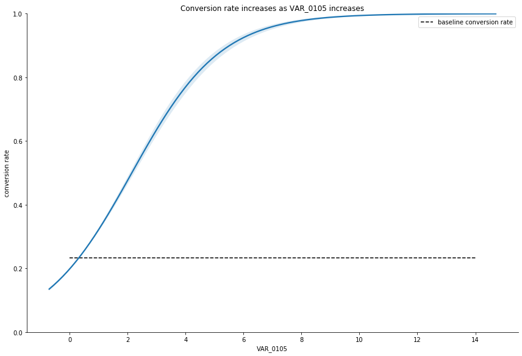

## Categorical Information

As with numeric data, the model can use categorical data to inform propensity scores. The plot below is similar to the one above, but instead of a numeric x axis, the x axis shows discreet values the variable can take. As with the numeric plot above, we have a black, dotted line indicating our baseline, 23% conversion rate. The distance between the top of the bars and the dotted line corresponds to increased precision from our baseline estimation. For example, the 8% of targets in the `CSC` group are much less likely to convert than the overall population.

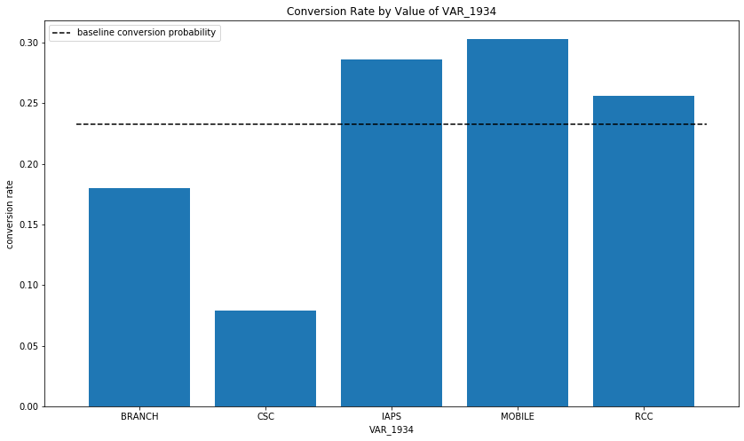

# Propensity Scoring

As we mentioned above, we want to build a machine learning model that can do a more precise job in propensity scoring than the humans who are currently performing the task. The current process assumes all customers have the 23% conversion rate we have realized from our previous campaigns. Now lets use the Random Forest model I built to score customers our model has never seen.

The plot below shows the conversion propensity scores assigned to each of the potential customers. Think of it as taking a coin for each customer (yellow if they converted, and blue if they didn't), and using the propensity score to pile them up along the x-axis. As you can see, the customers who converted tend to have higher propensity scores than those who didn't. The more separated these two piles (yellow and blue) are, the more useful our propensity score is.

Since the non-converting customers have a more tightly grouped mound, with a greater proportion of scores below the dashed line, we can tell that the model is better at evaluating customers who do not convert. This is good, it means we will be able to lower mailing costs by not sending promotions to customers with low scores.

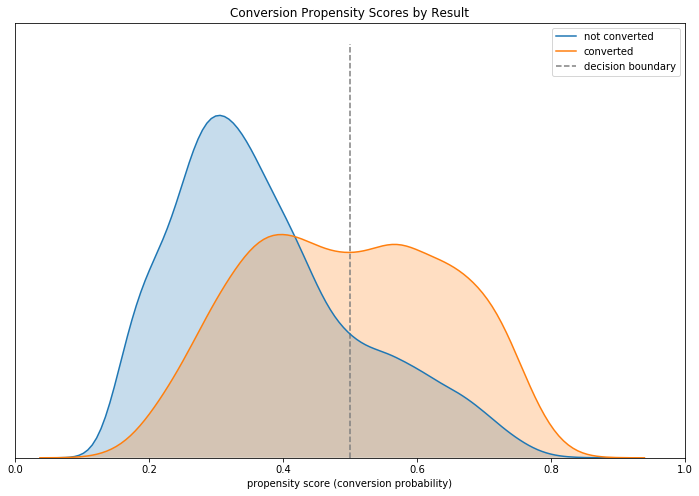

# Strategic Plan

Armed with a model that produces the propensity scores we examined above, we can optimize business operations to maximize profit. But first, now that we have a better understanding of the quality of propensity scoring our model will provide, lets extend our strategy illustration to show how we can best use these scores in our marketing campaign.

The upper two plots, below, remind us of the difference between current and machine propensity scoring.

The plot in the lower left shows which marketing targets our machine would chose to pursue. As you can see, this allows us to significantly cut marketing costs by not promoting to customers with low propensity scores.

The plot in the lower right shows whether those targets converted. You can see that allowing the machine to score potential customers and select those most likely to will result in a much higher conversion rate than the current strategy, where just 23% of our targets are converting. This allows us to maintain revenue by ensuring customers with high propensity scores receive promotional materials.

Taken together, the cost cutting from reducing the number of promotions sent, and the revenue maintenance from continuing to target high propensity customers, should result in higher profit. The simulation below shows the actual outcomes we could expect from implementing this optimized marketing strategy.

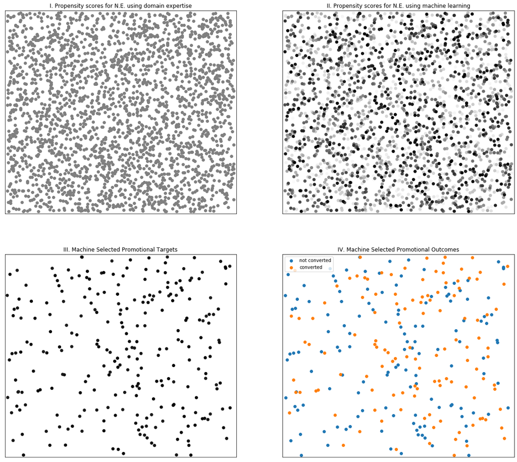

## Simulation

Using the same data we used to look at propensity scores, which the model has never seen, we can simulate real world outcomes by comparing two marketing campaign strategies with different budgets:

1. Current marketing strategy
   - Since the rows in the data set are actual marketing outcomes, this data represents the current strategy, so we can randomly send promotions to customers from the data set until we run out of budget
2. Optimized marketing strategy
   - Tell the machine the budget and let it score the customers and select which customers to send promotions

```
Assumed cost to per mailer: $5
Assumed revenue per conversion: $25
Assumed addressable market size: 97,304

Optimal spend: $24,500
Optimal revenue: $43,275
Optimal profit: $18,775
```

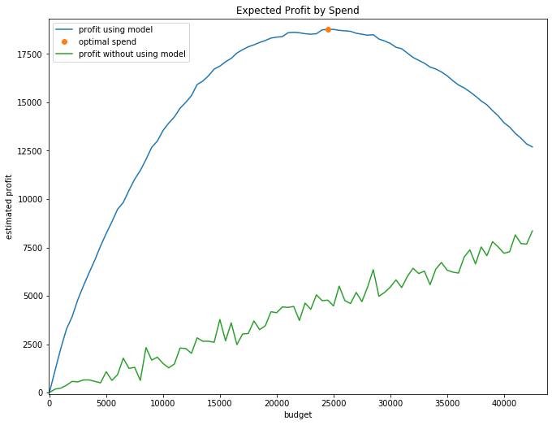

# Value Proposition

Machine propensity scoring will increase profit by

- Adding scalable precision to marketing campaigns
- Reducing marketing costs by reducing mail to low propensity customers
- Maintaining revenue growth by targeting high propensity customers first

Machine propensity scoring will also alow Springleaf to have more control over, and confidence in, their operating plan by allowing them to set their budget to optimize profit and/or ROI, and allowing them to estimate campaign outcomes.

# Next Steps

- Plan
  - Work through any additional concerns
- Build
  - Production model
    - Tune/optimize model
    - Implement optimization
  - Model performance suite
    - Report actual results
    - Validate projections against actual results
    - Detect any model drift
    - Model validation / training schedule
  - API
    - Requirements gathering
    - Proof of concept
    - Beta testing
- Launch

# Appendix

## Model Evaluation

```
Best Hyper Parametrs

clf__max_depth:5
clf__max_features:60
clf__n_estimators:1500
feature_selection__percentile:25
preprocess__num__imputer__n_neighbors:15


Best validation model macro avg F1: 0.6428470901684046

Confusion Matrix
Actual v Predicted (test set)
      no  yes
no   571  145
yes  118  105

Test Set Classification Report
              precision    recall  f1-score   support

           0       0.83      0.80      0.81       716
           1       0.42      0.47      0.44       223

    accuracy                           0.72       939
   macro avg       0.62      0.63      0.63       939
weighted avg       0.73      0.72      0.73       939

Test roc auc: 0.634
```

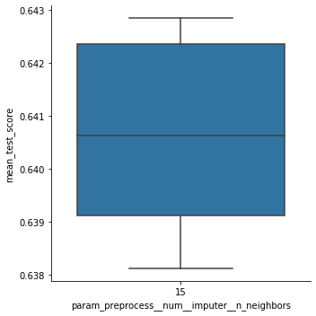

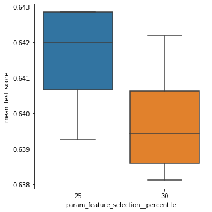

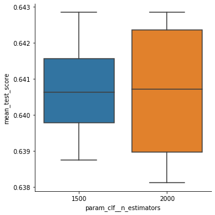

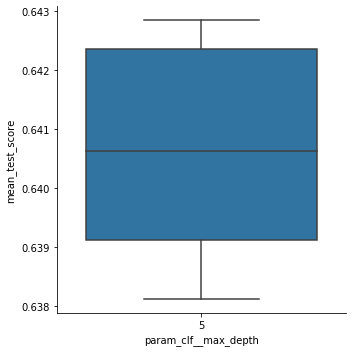

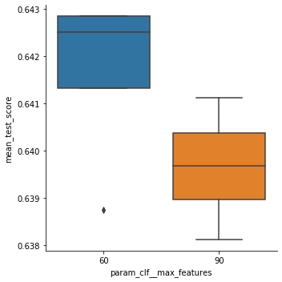